# Temporal structure in weekly K time series

# 3. Methods

The analysis begins with a visual inspection of weekly K trajectories for each participant. The main statistical analysis then evaluates lag-1 autocorrelation, which quantifies the association between a participant’s K value at a given week and the value observed in the previous week.

To test whether this week-to-week persistence is stronger than expected by chance, a surrogate analysis is performed. For each participant, K values are randomly shuffled many times to generate a null distribution of lag-1 correlations. The observed lag-1 correlation is then compared with this surrogate distribution.

Additional exploratory analyses are also included, such as autocorrelation across multiple lags and detrended fluctuation analysis (DFA), in order to examine broader temporal structure in the K time series.

```r
# Create lagged K values within each participant and keep only consecutive weeks
# This ensures that lag-1 correlation is computed from valid week-to-week pairs
df_lag <- df_long %>%
  group_by(participant) %>%
  arrange(Semaine, .by_group = TRUE) %>%
  mutate(
    prev_week = lag(Semaine),
    K_lag1 = lag(K),
    consecutive = (Semaine - prev_week == 1)
  ) %>%
  ungroup()

head(df_lag, 15)
```

```
## # A tibble: 15 × 6
##    Semaine participant     K prev_week K_lag1 consecutive
##      <dbl> <chr>       <dbl>     <dbl>  <dbl> <lgl>
##  1       1 K1A          1           NA  NA    NA
##  2       2 K1A          0.54         1   1    TRUE
##  3       3 K1A          0.55         2   0.54 TRUE
##  4       4 K1A          0.54         3   0.55 TRUE
##  5       5 K1A          0.73         4   0.54 TRUE
##  6       6 K1A          0.72         5   0.73 TRUE
##  7       7 K1A          0.72         6   0.72 TRUE
##  8       8 K1A          0.58         7   0.72 TRUE
##  9       9 K1A          0.73         8   0.58 TRUE
## 10      10 K1A          0.74         9   0.73 TRUE
## 11      11 K1A          0.9         10   0.74 TRUE
## 12      12 K1A          0.82        11   0.9  TRUE
## 13      13 K1A          0.65        12   0.82 TRUE
## 14      14 K1A          0.75        13   0.65 TRUE
## 15      15 K1A          0.64        14   0.75 TRUE
```

```r
df_lag_valid <- df_lag %>%
  filter(consecutive == TRUE)

df_lag_valid %>%
  count(participant)
```

```
## # A tibble: 6 × 2
##   participant     n
##   <chr>       <int>
## 1 K1A            58
## 2 K2A           110
## 3 K3A            51
## 4 K4A            55
## 5 K5A            82
## 6 K6A            86
```

```r
acf_results <- df_lag_valid %>%
  group_by(participant) %>%
  summarise(
    lag1_acf = cor(K, K_lag1, use = "complete.obs"),
    n_pairs = n()
  )

acf_results
```

```
## # A tibble: 6 × 3
##   participant lag1_acf n_pairs
##   <chr>          <dbl>   <int>
## 1 K1A            0.185      58
## 2 K2A            0.597     110
## 3 K3A            0.235      51
## 4 K4A            0.199      55
## 5 K5A            0.442      82
## 6 K6A            0.613      86
```

The table below summarises the main lag-1 surrogate analysis for each participant. It reports the observed lag-1 autocorrelation, the surrogate-based reference interval, and the associated p-value.

```r
# Compare observed lag-1 correlation with a null distribution obtained by randomly shuffling K values within each participant.
# If observed correlation is outside the surrogate interval, this suggests non-random temporal structure.
set.seed(123)

n_surrogates <- 1000

surrogate_results <- df_lag_valid %>%
  group_by(participant) %>%
  group_modify(~{
    observed <- cor(.x$K, .x$K_lag1, use = "complete.obs")

    shuffled <- replicate(n_surrogates, {
      shuffled_K <- sample(.x$K)
      cor(shuffled_K, .x$K_lag1, use = "complete.obs")
    })

    tibble(
      observed_acf = observed,
      shuffled_mean = mean(shuffled, na.rm = TRUE),
      shuffled_sd = sd(shuffled, na.rm = TRUE),
      lower_2.5 = quantile(shuffled, 0.025, na.rm = TRUE),
      upper_97.5 = quantile(shuffled, 0.975, na.rm = TRUE),
      p_two_sided = mean(abs(shuffled) >= abs(observed), na.rm = TRUE)
    )
  }) %>%
  ungroup()

surrogate_results
```

```
## # A tibble: 6 × 7
##   participant observed_acf shuffled_mean shuffled_sd lower_2.5 upper_97.5
##   <chr>              <dbl>         <dbl>       <dbl>     <dbl>      <dbl>
## 1 K1A                0.185      0.00207       0.133     -0.253      0.257
## 2 K2A                0.597      0.00151       0.0960    -0.191      0.183
## 3 K3A                0.235     -0.000121      0.146     -0.288      0.279
## 4 K4A                0.199      0.00278       0.139     -0.275      0.275
## 5 K5A                0.442     -0.00486       0.112     -0.215      0.217
## 6 K6A                0.613      0.00543       0.108     -0.202      0.213
## # ℹ 1 more variable: p_two_sided <dbl>
```

```r
#save the table
write_csv(surrogate_results, "results/lag1_surrogate_table.csv")
```

To make the surrogate comparison easier to interpret visually, the figure below shows each observed lag-1 correlation together with its participant-specific surrogate 95% interval (2.5th–97.5th percentile of the shuffled surrogate distribution).

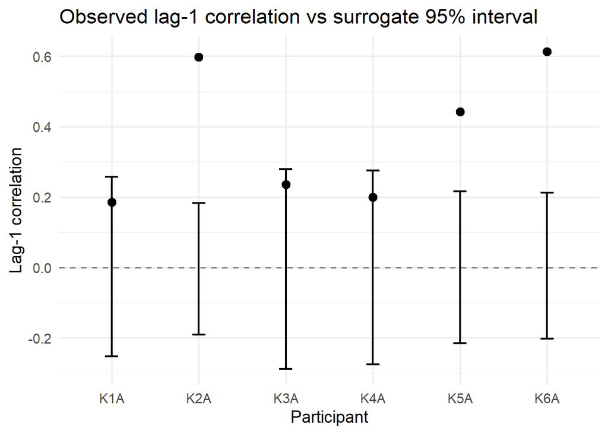

```r
# Visualize whether the observed lag-1 correlation exceeds the
# participant-specific surrogate 95% interval
library(ggplot2)

p_surrogate <- ggplot(surrogate_results, aes(x = participant, y = observed_acf)) +
  geom_hline(yintercept = 0, linetype = "dashed", color = "grey50") +
  geom_errorbar(
    aes(ymin = lower_2.5, ymax = upper_97.5),
    width = 0.15,
    linewidth = 0.8
  ) +
  geom_point(size = 3) +
  labs(
    title = "Observed lag-1 correlation vs surrogate 95% interval",
    x = "Participant",
    y = "Lag-1 correlation"
  ) +
  theme_minimal(base_size = 14)

p_surrogate
```

# 4. Results

The surrogate comparison provides the main inferential result of this report. Three participants (K2A, K5A, and K6A) showed observed lag-1 correlations clearly above the upper bound of the surrogate 95% interval, suggesting stronger-than-random week-to-week persistence. In contrast, K1A, K3A, and K4A remained within the surrogate interval, indicating weaker evidence for non-random short-term temporal structure.

Beyond the main lag-1 analysis, autocorrelation across multiple lags was examined as an exploratory extension. This allows a broader description of how temporal dependence changes across increasing lag values.

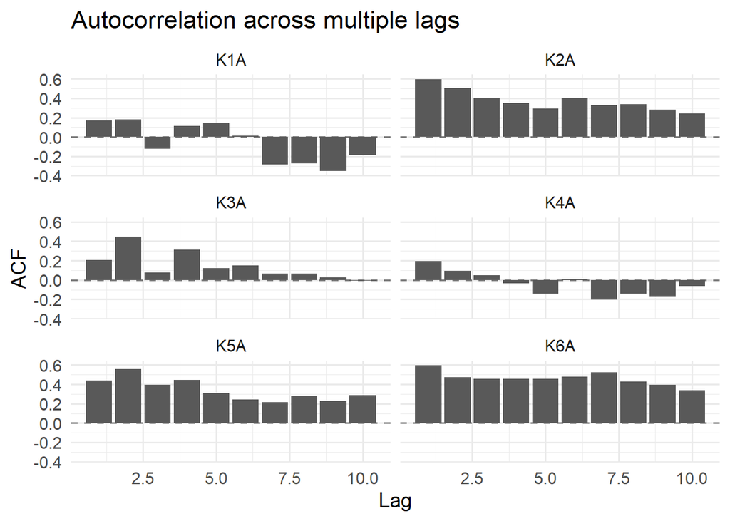

```r
# This exploratory section extends the analysis beyond lag-1 and shows
# how autocorrelation changes across several time lags.
max_lag <- 10

acf_multi <- df_long %>%
  group_by(participant) %>%
  group_modify(~{
    x <- .x %>%
      arrange(Semaine) %>%
      pull(K) %>%
      na.omit()

    acf_obj <- acf(x, lag.max = max_lag, plot = FALSE)

    tibble(
      lag = as.numeric(acf_obj$lag[-1]),
      acf = as.numeric(acf_obj$acf[-1])
    )
  }) %>%
  ungroup()

ggplot(acf_multi, aes(x = lag, y = acf)) +
  geom_hline(yintercept = 0, linetype = "dashed", color = "grey50") +
  geom_col() +
  facet_wrap(~ participant, ncol = 2) +
  labs(
    title = "Autocorrelation across multiple lags",
    x = "Lag",
    y = "ACF"
  ) +
  theme_minimal(base_size = 14)
```

As a complementary analysis, DFA was used to examine whether the weekly K series also showed broader temporal structure beyond immediate lag-1 persistence.

```r
# DFA is included here as an exploratory complexity-oriented analysis.
# It estimates scaling behaviour in each participant's K time series.
library(nonlinearTseries)
library(tibble)
library(dplyr)

dfa_results <- df_long %>%
  group_by(participant) %>%
  group_modify(~{
    x <- .x %>%
      arrange(Semaine) %>%
      pull(K) %>%
      na.omit()

    dfa_obj <- dfa(
      time.series = x,
      window.size.range = c(4, floor(length(x) / 4)),
      npoints = 15,
      do.plot = FALSE
    )

    fit <- lm(log(dfa_obj$fluctuation.function) ~ log(dfa_obj$window.sizes))

    tibble(
      dfa_alpha = as.numeric(coef(fit)[2]),
      r_squared = summary(fit)$r.squared,
      n = length(x)
    )
  }) %>%
  ungroup()

dfa_results
```

```
## # A tibble: 6 × 4
##   participant dfa_alpha r_squared     n
##   <chr>           <dbl>     <dbl> <int>
## 1 K1A             0.922     0.897    59
## 2 K2A             1.03      0.966   111
## 3 K3A             0.767     0.886    52
## 4 K4A             0.808     0.945    56
## 5 K5A             0.784     0.911    83
## 6 K6A             0.734     0.956    87
```

The observed DFA alpha values were then compared with shuffled surrogate series in order to assess whether the apparent scaling behaviour was stronger than expected by chance.

```r
# Compare observed DFA alpha with shuffled surrogates to assess whether the apparent scaling structure is stronger than expected by chance.
compute_dfa_alpha <- function(x) {
  x <- na.omit(x)

  if (length(x) < 20) return(NA_real_)

  dfa_obj <- dfa(
    time.series = x,
    window.size.range = c(4, floor(length(x) / 4)),
    npoints = 15,
    do.plot = FALSE
  )

  fit <- lm(log(dfa_obj$fluctuation.function) ~ log(dfa_obj$window.sizes))
  as.numeric(coef(fit)[2])
}

set.seed(123)
n_surrogates <- 200

surrogate_dfa <- df_long %>%
  group_by(participant) %>%
  group_modify(~{
    x <- .x %>%
      arrange(Semaine) %>%
      pull(K) %>%
      na.omit()

    obs_alpha <- compute_dfa_alpha(x)

    null_alpha <- replicate(n_surrogates, {
      x_surr <- sample(x)
      compute_dfa_alpha(x_surr)
    })

    tibble(
      obs_alpha = obs_alpha,
      null_mean = mean(null_alpha, na.rm = TRUE),
      lower_2.5 = quantile(null_alpha, 0.025, na.rm = TRUE),
      upper_97.5 = quantile(null_alpha, 0.975, na.rm = TRUE),
      p_upper = mean(null_alpha >= obs_alpha, na.rm = TRUE)
    )
  }) %>%
  ungroup()

surrogate_dfa
```

```
## # A tibble: 6 × 6
##   participant obs_alpha null_mean lower_2.5 upper_97.5 p_upper
##   <chr>           <dbl>     <dbl>     <dbl>      <dbl>   <dbl>
## 1 K1A             0.922     0.589     0.370      0.856   0.01
## 2 K2A             1.03      0.535     0.368      0.732   0
## 3 K3A             0.767     0.595     0.338      0.896   0.12
## 4 K4A             0.808     0.589     0.355      0.858   0.06
## 5 K5A             0.784     0.567     0.377      0.765   0.01
## 6 K6A             0.734     0.569     0.394      0.761   0.075
```

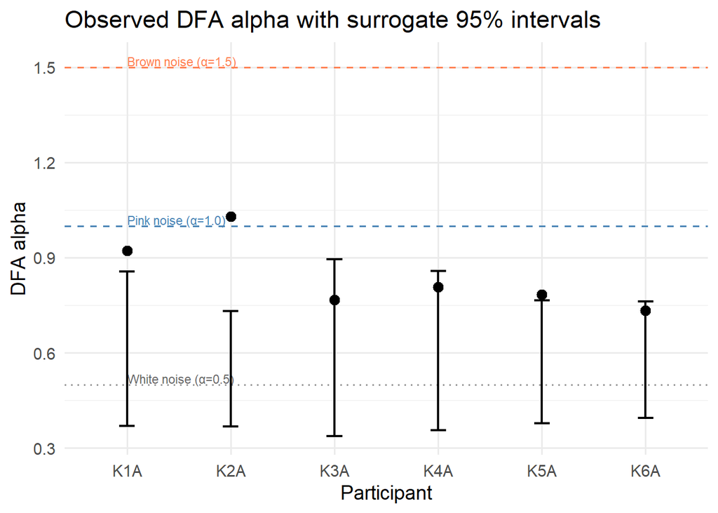

```r
# save the table
write_csv(surrogate_dfa, "results/dfa_surrogate_table.csv")

ggplot(surrogate_dfa, aes(x = participant, y = obs_alpha)) +
  geom_hline(yintercept = 0.5, linetype = "dotted", color = "grey60") +
  geom_hline(yintercept = 1.0, linetype = "dashed", color = "steelblue") +
  geom_hline(yintercept = 1.5, linetype = "dashed", color = "coral") +

  annotate("text", x = "K1A", y = 0.52, label = "White noise (\u03b1=0.5)",
           hjust = 0, size = 3, color = "grey40") +
  annotate("text", x = "K1A", y = 1.02, label = "Pink noise (\u03b1=1.0)",
           hjust = 0, size = 3, color = "steelblue") +
  annotate("text", x = "K1A", y = 1.52, label = "Brown noise (\u03b1=1.5)",
           hjust = 0, size = 3, color = "coral") +
  geom_errorbar(
    aes(ymin = lower_2.5, ymax = upper_97.5),
    width = 0.15,
    size = 0.8
  ) +
  geom_point(size = 3) +
  labs(
    title = "Observed DFA alpha with surrogate 95% intervals",
    x = "Participant",
    y = "DFA alpha"
  ) +
  theme_minimal(base_size = 14)
```

# 5. Discussion

The present analysis provides converging evidence that weekly K dynamics are not purely random and that the degree of temporal structure varies meaningfully across participants. The surrogate-based lag-1 analysis identified three participants (K2A, K5A, K6A) with short-term persistence exceeding chance, while the DFA analysis independently flagged K1A, K2A, and K5A as showing scaling structure beyond white noise. The convergence across these two methods — and in particular the near-pink-noise alpha for K2A — suggests that motivational dynamics may, in at least some individuals, exhibit the kind of 1/f temporal organisation that has been associated with self-organised criticality and adaptive flexibility in psychological systems. These findings should nonetheless be interpreted carefully. With only six participants and series of 52–111 observations, the DFA estimates are based on limited window ranges, and the power to detect reliable scaling behaviour is modest. The results are therefore best understood as exploratory: they are consistent with a pink-noise interpretation for some participants, but do not constitute definitive evidence. Future work with longer time series and larger samples would be needed to test whether 1/f structure in motivational dynamics is robust and replicable.

# 6. Conclusion

This report shows that weekly K time series can be analysed with relatively simple time-series tools in R, combining visualization, lag-1 autocorrelation, surrogate testing, and DFA. The main result is that some participant-level K series appear more temporally structured than would be expected by chance, supporting the idea that motivational dynamics may contain non-random short-term persistence. Complementary DFA results further suggest that, for some participants, this temporal structure may extend beyond immediate lag-1 dependence and may be compatible with intermediate dynamics between white noise and pink noise. Given the small number of participants and the limited series length, these DFA findings should be interpreted as exploratory rather than definitive.